# Analysing equity portfolios in R

Abstract

“Analysing equity portfolios in R” published in R News.

## Using the **portfolio** package

### Introduction

R is used by major financial institutions around the world to manage billions of dollars in equity (stock) portfolios. Unfortunately, there is no open source R package for facilitating this task. The **portfolio** package is meant to fill that gap. Using **portfolio**, an analyst can create an object of class `portfolioBasic` (weights only) or `portfolio` (weights and shares), examine its *exposures* to various factors, calculate its *performance* over time, and determine the *contributions* to performance from various categories of stocks. Exposures, performance and contributions are the basic building blocks of portfolio analysis.

### One Period, Long-Only

Consider a simple long-only portfolio formed from the universe of 30 stocks in the Dow Jones Industrial Average (DJIA) in January, 2005. Start by loading and examining the input data.

```
> library(portfolio)
> data(dow.jan.2005)
> summary(dow.jan.2005)
```

| symbol | name |
| --- | --- |
| Length:30 | Length:30 |
| Class :character | Class :character |
| Mode :character | Mode :character |

| price | sector |
| --- | --- |
| Min. : 21.0 | Industrials :6 |
| 1st Qu.: 32.1 | Staples :6 |
| Median : 42.2 | Cyclicals :4 |
| Mean : 48.6 | Financials :4 |
| 3rd Qu.: 56.0 | Technology :4 |
| Max. :103.3 | Communications:3 |
|  | (Other) :3 |
| cap.bil | month.ret |
| Min. : 22.6 | Min. :-0.12726 |
| 1st Qu.: 53.9 | 1st Qu.:-0.05868 |
| Median : 97.3 | Median :-0.02758 |
| Mean :126.0 | Mean :-0.02914 |
| 3rd Qu.:169.3 | 3rd Qu.: 0.00874 |
| Max. :385.9 | Max. : 0.04468 |

```
> head(dow.jan.2005)
```

|  | symbol | name | price |
| --- | --- | --- | --- |
| 140 | AA | ALCOA INC | 31.42 |
| 214 | MO | ALTRIA GROUP INC | 61.10 |
| 270 | AXP | AMERICAN EXPRESS CO | 56.37 |
| 294 | AIG | AMERICAN INTERNATIONAL GROUP | 65.67 |
| 946 | BA | BOEING CO | 51.77 |
| 1119 | CAT | CATERPILLAR INC | 97.51 |

|  | sector | cap.bil | month.ret |
| --- | --- | --- | --- |
| 140 | Materials | 27.35 | -0.060789 |
| 214 | Staples | 125.41 | 0.044681 |
| 270 | Financials | 70.75 | -0.051488 |
| 294 | Financials | 171.04 | 0.009441 |
| 946 | Industrials | 43.47 | -0.022600 |
| 1119 | Industrials | 33.27 | -0.082199 |

The DJIA consists of exactly 30 large US stocks. We provide a minimal set of information for constructing a long-only portfolio. Note that `cap.bil` is market capitalization in billions of dollars, `price` is the per share closing price on December 31, 2004, and `month.ret` is the one month return from December 31, 2004 through January 31, 2005.

In order to create an object of class `portfolioBasic`, we can use this data and form a portfolio on the basis of a “nonsense” variable like `price`.

```
> p <- new("portfolioBasic",
+   date = as.Date("2004-12-31"),
+   id.var = "symbol", in.var = "price",
+   sides = "long", ret.var = "month.ret",
+   data = dow.jan.2005)
```

An object of class “portfolioBasic” with 6 positions

Selected slots:  
name: Unnamed portfolio  
date: 2004-12-31  
in.var: price  
ret.var: month.ret  
type: equal  
size: quintile

```
> summary(p)
```

Portfolio: Unnamed portfolio

|  | count | weight |
| --- | --- | --- |
| Long: | 6 | 1 |

Top/bottom positions by weight:

| id | pct |
| --- | --- |
| 1 | AIG 16.7 |
| 2 | CAT 16.7 |
| 3 | IBM 16.7 |
| 4 | JNJ 16.7 |
| 5 | MMM 16.7 |
| 6 | UTX 16.7 |

In other words, we have formed a portfolio of the highest priced 6 stocks out of the 30 stocks in the DJIA. The `id.var` argument causes the portfolio to use `symbol` as the key for identifying securities throughout the analysis. `in.var` selects the variable by which stocks are ranked in terms of desirability. `sides` set to `long` specifies that we want a long-only portfolio. `ret.var` selects the return variable for measuring performance. In this case, we are interested in how the portfolio does for the month of January 2005.

The default arguments to `portfolioBasic` form equal-weighted positions; in this case, each of the 6 stocks has 16.67% of the resulting portfolio. The defaults also lead to a portfolio made up of the best 20% (or quintile) of the universe of stocks provided to the data argument. Since 20% of 30 is 6, there are 6 securities in the resulting portfolio.

### Exposures

Once we have a portfolio, the next step is to analyse its exposures. These can be calculated with respect to both numeric or factor variables. The method `exposure` will accept a vector of variable names.

```
> exposure(p, exp.var = c("price", "sector"))

numeric
  variable exposure
1   price      85.1
```

```
sector
  variable exposure
2 Industrials    0.500
1 Financials     0.167
3 Staples       0.167
4 Technology     0.167
```

The weighted average price of the portfolio is 85. In other words, since the portfolio is equal-weighted, the average share price of AIG, CAT, IBM, JNJ, MMM, and UTX is 85. This is a relatively high price, but makes sense since we explicitly formed the portfolio by taking the 6 highest priced stocks out of the DJIA.

Each of the 6 stocks is assigned a sector and 3 of them are Industrials. This compares to the 20% of the entire universe of 30 stocks that are in this sector. In other words, the portfolio has a much higher exposure to Industrials than the universe as a whole. Similarly, the portfolio has no stocks from the Communications, Cyclicals or Energy sectors despite the fact that these make up almost 27% of the DJIA universe.

### Performance

Time plays two roles in the portfolio class. First, there is the moment of portfolio formation. This is the instant when all of the data, except for future returns, is correct. After this moment, of course, things change. The price of AIG on December 31, 2004 was $65.67, but by January 5, 2005 it was $67.35.

The second role played by time on the portfolio class concerns future returns. `ret.var` specifies a return variable which measures the performance of individual stocks going forward. These returns can be of any duration — an hour, a day, a month, a year — but should generally start from the moment of portfolio formation. In this example, we are using one month forward returns. Now that we know the portfolio’s exposures at the start of the time period, we can examine its performance for the month of January.

```
> performance(p)
```

Total return: -1.71 %

```
Best/Worst performers:
  id weight    ret contrib
2 CAT  0.167 -0.08220 -0.01370
3 IBM  0.167 -0.05234 -0.00872
6 UTX  0.167 -0.02583 -0.00431
1 AIG  0.167  0.00944  0.00157
4 JNJ  0.167  0.02018  0.00336
5 MMM  0.167  0.02790  0.00465
```

The portfolio lost 1.7% of its value in January. The worst performing stock was CAT (Caterpillar), down more than 8%. The best performing stock was MMM

(3M), up almost 3%. The `contrib` (contribution) of each stock to the overall performance of the portfolio is simply its weight in the portfolio multiplied by its return. The sum of the 6 individual contributions yields -1.7%.

### Contributions

The contributions of individual stocks are not that interesting in and of themselves. More important is to examine summary statistics of the contributions across different categories of stocks. Consider the use of the contribution method:

```
> contribution(p, contrib.var = c("sector"))
```

```
sector
  variable weight contrib roic
5 Communications  0.000  0.00000  0.00000
6 Conglomerates  0.000  0.00000  0.00000
7 Cyclicals      0.000  0.00000  0.00000
8 Energy         0.000  0.00000  0.00000
1 Financials     0.167  0.00157  0.00944
2 Industrials    0.500 -0.01336 -0.02671
9 Materials      0.000  0.00000  0.00000
3 Staples        0.167  0.00336  0.02018
4 Technology     0.167 -0.00872 -0.05234
10 Utilities     0.000  0.00000  0.00000
```

`contribution`, like `exposure`, accepts a vector of variable names. In the case of `sector`, the contribution object displays the 10 possible values, the total weight of the stocks for each level and the sum of the contributions for those stocks. Only 4 of the 10 levels are represented by the stocks in the portfolio. The other 6 levels have zero weight and, therefore, zero contributions.

The sector with the biggest weight is Industrials, with half of the portfolio. Those 3 stocks did poorly, on average, in January and are therefore responsible for -1.3% in total losses. There is only a single Technology stock in the portfolio, IBM. Because it was down 5% for the month, its contribution was -0.87%. Since IBM is the only stock in its sector in the portfolio, the contribution for the sector is the same as the contribution for IBM.

Think about `roic` as useful in determining contributions on the margin. Imagine that you have the chance to move $1 out of one sector and into another. Where should that initial dollar come from? Not from the sector with the worst total contribution. Instead, the marginal dollar should come from the sector with the worst `roic` and should be placed into the sector with the best `roic`. In this example, we should move money out of Technology and into Staples.

contribution can also work with numeric variables.

```
> contribution(p, contrib.var = c("cap.bil"))
```

```
cap.bil
   rank   variable weight  contrib  roic
1  1 - low (22.6,50.9]  0.167 -0.013700 -0.08220
2      2 (50.9,71.1]  0.333  0.000345  0.00103
4      3 (71.1,131]  0.000  0.000000  0.00000
3      4 (131,191]  0.500 -0.003787 -0.00757
5  5 - high (191,386]  0.000  0.000000  0.00000
```

Analysing contributions only makes sense in the context of categories into which each position can be placed. So, we need to break up a numeric variable like `cap` into discrete, exhaustive categories. The `contribution` function provides various options for doing so, but most users will be satisfied with the default behavior of forming 5 equal sized quintiles based on the distribution of the variable in the entire universe.

In this example, we see that there are no portfolio holdings among the biggest 20% of stocks in the DJIA. Half the portfolio comes from stocks in the second largest quintile. Within each category, the analysis is the same as that above for sectors. The worst performing category in terms of total contribution is the smallest quintile. This category also has the lowest `roic`.

#### One Period Long-Short

Having examined a very simple long-only portfolio in order to explain the concepts behind *exposures*, *performance* and *contributions*, it is time to consider a more complex case, a long-short portfolio which uses the same underlying data.

```
> p <- new("portfolioBasic",
+   date = as.Date("2004-12-31"),
+   id.var = "symbol", in.var = "price",
+   type = "linear", sides = c("long",
+     "short"), ret.var = "month.ret",
+   data = dow.jan.2005)
```

An object of class “portfolioBasic” with 12 positions

Selected slots:  
name: Unnamed portfolio  
date: 2004-12-31

```
in.var: price
ret.var: month.ret
type: linear
size: quintile
```

```
> summary(p)
```

Portfolio: Unnamed portfolio

|  | count | weight |
| --- | --- | --- |
| Long: | 6 | 1 |
| Short: | 6 | -1 |

Top/bottom positions by weight:

|  | id | pct |
| --- | --- | --- |
| 12 | UTX | 28.57 |
| 5 | IBM | 23.81 |
| 2 | CAT | 19.05 |
| 8 | MMM | 14.29 |
| 1 | AIG | 9.52 |
| 10 | PFE | -9.52 |
| 9 | MSFT | -14.29 |
| 11 | SBC | -19.05 |
| 6 | INTC | -23.81 |
| 4 | HPQ | -28.57 |

Besides changing to a long-short portfolio, we have also provided a value of “linear” to the `type` argument. As the summary above shows, this yields a portfolio in which the weights on the individual positions are (linearly) proportional to their share prices. At the end of 2004, the lowest priced stock in the DJIA was HPQ (Hewlett-Packard) at $20.97. Since we are using price as our measure of desirability, HPQ is the biggest short position. Since we have not changed the default value for `size` from “quintile,” there are still 6 positions per side.

```
> plot(p)
```

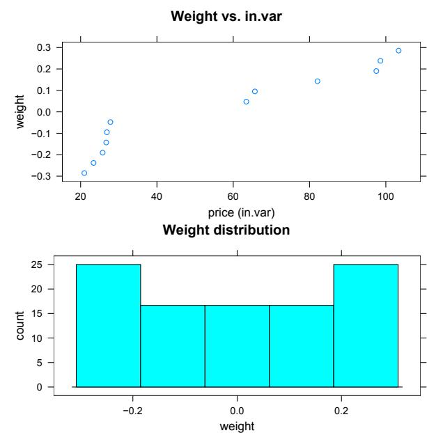

Figure 1: Plot of a portfolioBasic object.

Figure 1 shows the result of calling `pplot` on this portfolio object. The top plot displays the relationship between position weights and their corresponding in. `var` values, while the bottom plot shows a histogram of position weights.

The display for the exposure object is now somewhat different to accommodate the structure of a long-short portfolio.

```
> exposure(p, exp.var = c("price", "sector"))

numeric
  variable long short exposure
1   price  92.6 -24.2    68.4

sector
      variable   long   short exposure
2   Industrials  0.6190  0.0000  0.6190
1    Financials  0.0952  0.0000  0.0952
3     Staples    0.0476 -0.0952 -0.0476
5 Communications 0.0000 -0.2381 -0.2381
4    Technology  0.2381 -0.6667 -0.4286
```

The long exposure to price is simply the weighted average of price on the long side of the portfolio, where the weighting is done in proportion to the size of the position in each stock. The same is true on the short side. Since a linear weighting used here emphasises the tail of the distribution, the long exposure is greater than the long exposure of the equal weighted portfolio considered above, $93 versus $85.

Since the weights on the short side are actually negative — in the sense that we are negatively exposed to positive price changes in these stocks — the weighted average on the short side for a positive variable like price is also negative. Another way to read this is to note that the weighted average price on the short side is about $24 but that the portfolio has a negative exposure to this number because these positions are all on the short side.

One reason for the convention of using a negative sign for short side exposures is that doing so makes the overall exposure of the portfolio into a simple summation of the long and short exposures. (Note the assumption that the weights on both sides are equal. In future versions of the **portfolio** package, we hope to weaken these and other requirements.) For this portfolio, the overall exposure is 68. Because the portfolio is long the high priced stocks and short the low priced ones, the portfolio has a positive exposure to the price factor. Colloquially, we are “long price.”

A similar analysis applies to sector exposures. We have 62% of our long holdings in Industrials but zero of our short holdings. We are, therefore, 62% long Industrials. We have 24% of the longs holdings in Technology, but 67% of the short holdings; so we are 43% short Technology.

Calling `pplot` on the exposure object produces a bar chart for each exposure category, as seen in Figure 2. Since all numeric exposures are grouped together, a plot of numeric exposure may only make sense if all numeric variables are on the same scale. In this example, the only numeric exposure we have calculated is that to price.

```
> plot(exposure(p, exp.var = c("price",
+       "sector")))
```

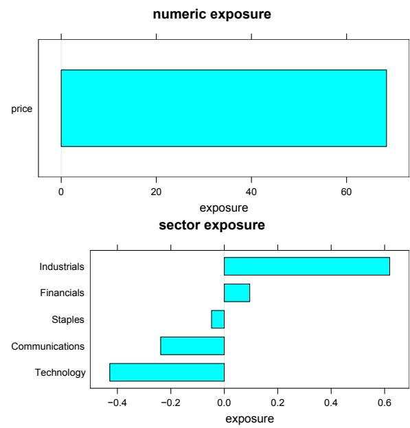

Figure 2: Plot of an exposure object for a single period. Bar charts are sorted by exposure.

The performance object is similar for a long-short portfolio.

```
> performance(p)

Total return:  2.19 %

Best/Worst performers:
      id weight      ret  contrib
2   CAT  0.1905 -0.08220 -0.01566
5   IBM  0.2381 -0.05234 -0.01246
12  UTX  0.2857 -0.02583 -0.00738
3   DIS -0.0476  0.02986 -0.00142
1   AIG  0.0952  0.00944  0.00090
8   MMM  0.1429  0.02790  0.00399
6  INTC -0.2381 -0.04019  0.00957
10  PFE -0.0952 -0.10152  0.00967
11  SBC -0.1905 -0.06617  0.01260
4   HPQ -0.2857 -0.06581  0.01880
```

The portfolio was up 2.2% in January. By default, the summary of the performance object only provides the 5 worst and best contributions to return. HPQ was the biggest winner because, though it was only down 7% for the month, its large weighting caused it to contribute almost 2% to overall performance. The 19% weight of CAT in the portfolio placed it as only the third largest position on the long side, but its -8% return for the month made it the biggest drag on performance.

The contribution function provides similar output for a long-short portfolio.

```
> contribution(p, contrib.var = c("cap.bil",
+ "sector"))

cap.bil
   rank   variable weight  contrib    roic
1  1 - low (22.6,50.9] 0.0952 -0.01566 -0.16440
2      2 (50.9,71.1] 0.3810  0.01399  0.03671
3      3 (71.1,131] 0.0952  0.01260  0.13235
4      4 (131,191] 0.3095 -0.00103 -0.00334
5  5 - high (191,386] 0.1190  0.01202  0.10098

sector
      variable weight contrib    roic
1 Communications 0.1190  0.0112  0.0939
6 Conglomerates 0.0000  0.0000  0.0000
7    Cyclicals 0.0000  0.0000  0.0000
8      Energy 0.0000  0.0000  0.0000
2    Financials 0.0476  0.0009  0.0189
3   Industrials 0.3095 -0.0191 -0.0616
9    Materials 0.0000  0.0000  0.0000
4      Staples 0.0714  0.0106  0.1488
5    Technology 0.4524  0.0183  0.0404
10   Utilities 0.0000  0.0000  0.0000
```

As in the last example, the *weight* column reflects the proportion of the portfolio invested in each category. In this case, we have 45% of the total capital (or weight) of the long and short sides *considered together* invested in the Technology sector. We know from the exposure results above that most of this is invested on the short side, but in the context of contributions, it does not matter on which side the capital is deployed.

```
> plot(contribution(p, contrib.var = c("cap.bil",
+ "sector")))
```

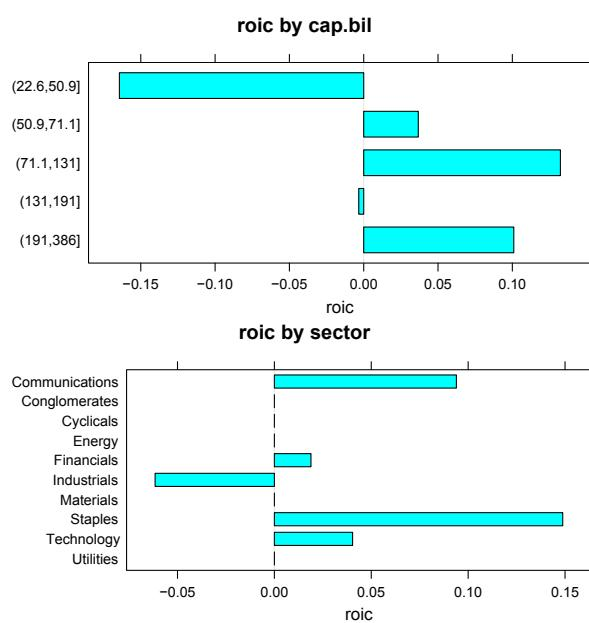

Figure 3: Plot of a contribution object for a single period.

Plotting objects of class *contribution* produces output similar to plotting exposures, as can be seen in Figure 3. This time, however, we see values of *roic* plotted against the categories that make up each *contrib.var*. For numeric variables, *roic* for each interval is shown; numeric intervals will always appear in order.

#### Multi-Period, Long-Short

Analysing a portfolio for a single time period is a useful starting point, but any serious research will require considering a collection of portfolios over time. The help pages of the **portfolio** package provide detailed instructions on how to construct a *portfolioHistory* object. Here, we will just load up the example object provided with the package and consider the associated methods for working with it.

```
> data(global.2004.history)
> global.2004.history
```

An object of class “portfolioHistory”  
Contains:

Object of class “exposureHistory”  
Number of periods: 12  
Period range: 2003-12-31 – 2004-11-30  
Data class: exposure  
Variables: numeric currency sector

Object of class “performanceHistory”  
Number of periods: 12  
Period range: 2003-12-31 – 2004-11-30  
Data class: performance

Object of class “contributionHistory”  
Number of periods: 12  
Period range: 2003-12-31 – 2004-11-30  
Data class: contribution  
Variables: currency sector liq.w

Note that the portfolios analysed in this object were created on a monthly frequency for 2004 using a universe of the 500 largest global stocks each month. Market capitalization in billions of dollars (*cap.bil*) was used as a measure of desirability, so the portfolio is long the mega-large caps and short the merely typical large caps.

We have designed the architecture of the **portfolio** package so that working with multi-period portfolios is similar to working with single period portfolios. For starters, we can call the *exposure* method on objects of class *portfolioHistory* just as we called them on objects of class *portfolio*. An added call to *summary* prints a summary of the returned object.

```
> summary(exposure(global.2004.history))
```

Mean exposure:  
numeric

|  | variable | long | short | exposure |
| --- | --- | --- | --- | --- |
| 11 | cap.bil | 109.20 | -10.483 | 98.71 |
| 1 | liq.w | 1.22 | 0.822 | 2.04 |

#### currency

|  | variable | long | short | exposure |
| --- | --- | --- | --- | --- |
| 6 | JPY | 0.062978 | -0.158931 | -0.095952 |
| 8 | SEK | 0.000948 | -0.040208 | -0.039260 |
| 5 | HKD | 0.000000 | -0.017283 | -0.017283 |
| 1 | AUD | 0.001242 | -0.005734 | -0.004491 |
| 7 | NOK | 0.000000 | -0.003949 | -0.003949 |
| 9 | SGD | 0.000000 | -0.000438 | -0.000438 |
| 3 | EUR | 0.179902 | -0.176904 | 0.002998 |
| 4 | GBP | 0.113589 | -0.109119 | 0.004470 |
| 2 | CHF | 0.042340 | -0.019232 | 0.023108 |
| 10 | USD | 0.598999 | -0.468202 | 0.130797 |

#### sector

|  | variable | long | short | exposure |
| --- | --- | --- | --- | --- |
| 10 | Utilities | 0.00803 | -0.08832 | -0.080290 |
| 3 | Cyclicals | 0.04980 | -0.12475 | -0.074945 |
| 7 | Materials | 0.00112 | -0.05876 | -0.057636 |
| 6 | Industrials | 0.04147 | -0.09762 | -0.056152 |
| 2 | Conglomerates | 0.00000 | -0.00356 | -0.003563 |
| 9 | Technology | 0.08784 | -0.08730 | 0.000545 |
| 8 | Staples | 0.24521 | -0.23168 | 0.013532 |
| 5 | Financials | 0.24544 | -0.19245 | 0.052982 |
| 4 | Energy | 0.10328 | -0.03456 | 0.068719 |
| 1 | Communications | 0.19144 | -0.05385 | 0.137588 |

The difficulty in considering exposures — basically a static concept about how the portfolio looks at this moment — in the context of a time series of portfolio objects is that it is not obvious how to summarize the exposures over time, especially in the context of a portfolio whose overall size is changing. In this release of the **portfolio** package, we will simply report the average exposure for all time periods.

For this example portfolio, it is easy to see that the portfolio is long the biggest stocks. The average market capitalization is over $100 billion on the long side versus only $10 billion on the short side. This cap exposure causes the portfolio to take a similar “bet” on liquidity, since larger stocks are, on average, more liquid than smaller stocks. The `liq.w` variable is our measure of liquidity — basically how much stock is traded on a “typical” day — scaled to have mean 0 and variance 1 for the universe.

The currency and sector exposures are, likewise, simple averages of the of the 12 monthly exposures. Even though the portfolio is constructed without reference to currency or sector, it still ends up with non-trivial exposures to these variables. In a typical month, the portfolio is 14% long Communications and 10% short Japan.

Plotting the `exposureHistory` object yields box and whisker plots of net exposure for each exposure variable, as in Figure 4.

```
> plot(exposure(global.2004.history))
```

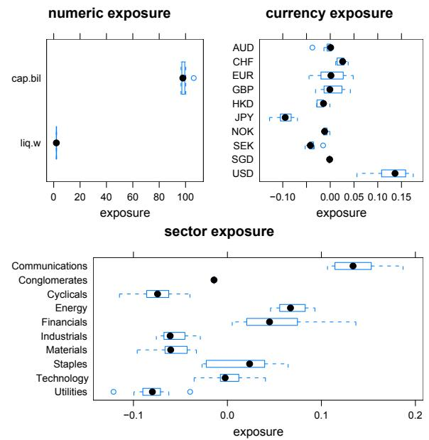

Figure 4: Plot of an exposureHistory object.

The performance method aggregates performance for each individual time period into an overall figure and provides a listing of the largest contributions.

```
> summary(performance(global.2004.history))
```

Performance summary (frequency = 12):

|  | ret |
| --- | --- |
| mean | -0.0081 |
| mean (ann) | -0.0971 |
| sd | 0.0152 |
| sd (ann) | 0.0527 |
| sharpe | -1.8439 |

Best period:

|  | date | ret |
| --- | --- | --- |
| 2004-03-31 | 2004-03-31 | 0.0149 |

Worst period:

|  | date | ret |
| --- | --- | --- |
| 2004-10-31 | 2004-10-31 | -0.0292 |

Top/Bottom performers (total contribution):

|  | id | contrib |
| --- | --- | --- |
| 140 | EBAY | 0.00423 |
| 231 | MRW.LN | 0.00387 |
| 234 | MU | 0.00357 |
| 338 | XOM | 0.00337 |
| 196 | JNJ | 0.00333 |
| 211 | LTR | -0.00416 |
| 323 | VOLVB.SS | -0.00453 |
| 329 | WLP | -0.00474 |
| 227 | MON | -0.00494 |
| 11 | 5201 | -0.00555 |

The best month for the portfolio was April 2004 when it earned 1.5%. The worst month was a loss of almost 3% in November. The biggest contributor on the positive side was EBAY. The mean annualized return of the portfolio is almost -10%; the annualized volatility is 5.3%. Sharpe ratios — defined[^1] as the mean return divided by the standard deviation of return — are generally not provided for unprofitable portfolios, but the ratio here is -1.8.

Note that the `portfolioHistory` object does not keep a record of every position for each time period. By design, it only retains summary information, albeit on a stock-by-stock basis. We want to be able to use this package for high frequency data — say, a decade worth of daily portfolios — so it is not easy (or even possible) to manipulate an object which maintains information for every stock for each time period.

As with the exposure method, the contribution method works with `portfolioHistory` objects in the same way that it works with `portfolio` objects.

```
> summary(contribution(global.2004.history))
```

#### Mean contribution:

| currency |  |  |  |  |
| --- | --- | --- | --- | --- |
|  | variable | weight | contrib | roic |
| 1 | AUD | 0.003488 | -0.00014179 | -0.02622 |
| 2 | CHF | 0.030786 | 0.00000868 | -0.00291 |
| 11 | DKK | 0.000000 | 0.00000000 | 0.00000 |
| 3 | EUR | 0.178403 | -0.00104765 | -0.00620 |
| 4 | GBP | 0.111354 | -0.00048120 | -0.00409 |
| 5 | HKD | 0.008641 | 0.00011748 | -0.00720 |
| 6 | JPY | 0.110954 | 0.00005111 | -0.00273 |
| 21 | NOK | 0.001974 | -0.00012765 | -0.03745 |
| 7 | SEK | 0.020578 | -0.00111390 | -0.04674 |
| 31 | SGD | 0.000219 | -0.00000963 | -0.01264 |
| 8 | USD | 0.533601 | -0.00534746 | -0.00996 |

| sector |  |  |  |  |
| --- | --- | --- | --- | --- |
|  | variable | weight | contrib | roic |
| 1 | Communications | 0.12610 | 0.0008478 | 0.00814 |
| 11 | Conglomerates | 0.00179 | -0.0000746 | -0.01039 |
| 2 | Cyclicals | 0.08961 | -0.0025430 | -0.02863 |
| 3 | Energy | 0.07077 | 0.0008145 | 0.01384 |
| 4 | Financials | 0.22484 | -0.0010191 | -0.00416 |
| 5 | Industrials | 0.07153 | -0.0014918 | -0.01990 |
| 6 | Materials | 0.03067 | -0.0002470 | -0.01246 |
| 7 | Staples | 0.24511 | -0.0036175 | -0.01483 |
| 8 | Technology | 0.09007 | 0.0002594 | 0.00231 |
| 9 | Utilities | 0.04950 | -0.0011930 | -0.02607 |

| liq.w |  |  |  |  |
| --- | --- | --- | --- | --- |
|  | variable | weight | contrib | roic |
| 1 | 1 - low | 0.2628 | -0.00390 | -0.0140 |
| 2 | 2 | 0.1607 | -0.00545 | -0.0349 |

```
3      3 0.0668 -0.00136 -0.0197
4      4 0.0952 -0.00167 -0.0156
5 5 - high 0.4144 0.00384 0.0090
```

Again, the basic approach consists of calculating the contributions for each time period separately, saving those results, and then presenting an average for the entire period.

Figure 5 shows the plot of the resulting `contributionHistory` object. As with exposure history, the box and whisker plot shows the median and quartile range of variable values over the given time period.

```
> plot(contribution(global.2004.history))
```

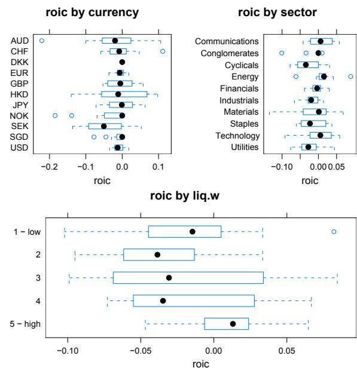

Figure 5: Plot of a contributionHistory object.

### Conclusion

The current release of the portfolio package is meant to serve as a proof-of-concept. Relatively sophisticated portfolio analytics are possible using an open source package. Although money management is largely a zero-sum game — every dollar that I make is a dollar that someone else has lost — there is no reason why we might not cooperate on the tools that we all use.

[^1]: The definition of the Sharpe ratio subtracts the risk free rate from the mean return in the numerator. But, in the context of a long-short portfolio, this is typically ignored.